# Risk Factor Analysis

## Outcome Variable

**Outcome Variable:** swasted

## Predictor Variables

**Intervention Variable:** month

**Adjustment Set:**

unadjusted

## Stratifying Variables

The analysis was stratified on these variable(s):

- agecat
- studyid
- country

## Data Summary

| agecat | studyid | country | month | swasted | n_cell | n |
| --- | --- | --- | --- | --- | --- | --- |
| Birth | ki0047075b-MAL-ED | BANGLADESH | 1 | 0 | 19 | 241 |
| Birth | ki0047075b-MAL-ED | BANGLADESH | 1 | 1 | 0 | 241 |
| Birth | ki0047075b-MAL-ED | BANGLADESH | 2 | 0 | 21 | 241 |
| Birth | ki0047075b-MAL-ED | BANGLADESH | 2 | 1 | 0 | 241 |
| Birth | ki0047075b-MAL-ED | BANGLADESH | 3 | 0 | 23 | 241 |
| Birth | ki0047075b-MAL-ED | BANGLADESH | 3 | 1 | 2 | 241 |
| Birth | ki0047075b-MAL-ED | BANGLADESH | 4 | 0 | 19 | 241 |
| Birth | ki0047075b-MAL-ED | BANGLADESH | 4 | 1 | 2 | 241 |
| Birth | ki0047075b-MAL-ED | BANGLADESH | 5 | 0 | 20 | 241 |
| Birth | ki0047075b-MAL-ED | BANGLADESH | 5 | 1 | 0 | 241 |
| Birth | ki0047075b-MAL-ED | BANGLADESH | 6 | 0 | 8 | 241 |
| Birth | ki0047075b-MAL-ED | BANGLADESH | 6 | 1 | 0 | 241 |
| Birth | ki0047075b-MAL-ED | BANGLADESH | 7 | 0 | 21 | 241 |
| Birth | ki0047075b-MAL-ED | BANGLADESH | 7 | 1 | 0 | 241 |
| Birth | ki0047075b-MAL-ED | BANGLADESH | 8 | 0 | 21 | 241 |
| Birth | ki0047075b-MAL-ED | BANGLADESH | 8 | 1 | 1 | 241 |
| Birth | ki0047075b-MAL-ED | BANGLADESH | 9 | 0 | 19 | 241 |
| Birth | ki0047075b-MAL-ED | BANGLADESH | 9 | 1 | 1 | 241 |
| Birth | ki0047075b-MAL-ED | BANGLADESH | 10 | 0 | 22 | 241 |
| Birth | ki0047075b-MAL-ED | BANGLADESH | 10 | 1 | 1 | 241 |
| Birth | ki0047075b-MAL-ED | BANGLADESH | 11 | 0 | 15 | 241 |
| Birth | ki0047075b-MAL-ED | BANGLADESH | 11 | 1 | 0 | 241 |
| Birth | ki0047075b-MAL-ED | BANGLADESH | 12 | 0 | 25 | 241 |
| Birth | ki0047075b-MAL-ED | BANGLADESH | 12 | 1 | 1 | 241 |
| Birth | ki0047075b-MAL-ED | BRAZIL | 1 | 0 | 9 | 183 |
| Birth | ki0047075b-MAL-ED | BRAZIL | 1 | 1 | 0 | 183 |
| Birth | ki0047075b-MAL-ED | BRAZIL | 2 | 0 | 19 | 183 |
| Birth | ki0047075b-MAL-ED | BRAZIL | 2 | 1 | 0 | 183 |
| Birth | ki0047075b-MAL-ED | BRAZIL | 3 | 0 | 17 | 183 |
| Birth | ki0047075b-MAL-ED | BRAZIL | 3 | 1 | 0 | 183 |

[output cut: 1626 more lines]

The following strata were considered:

- agecat: 24 months, studyid: ki0047075b-MAL-ED, country: BANGLADESH
- agecat: 24 months, studyid: ki0047075b-MAL-ED, country: BRAZIL
- agecat: 24 months, studyid: ki0047075b-MAL-ED, country: INDIA
- agecat: 24 months, studyid: ki0047075b-MAL-ED, country: NEPAL
- agecat: 24 months, studyid: ki0047075b-MAL-ED, country: PERU
- agecat: 24 months, studyid: ki0047075b-MAL-ED, country: SOUTH AFRICA
- agecat: 24 months, studyid: ki0047075b-MAL-ED, country: TANZANIA, UNITED REPUBLIC OF
- agecat: 24 months, studyid: ki1000108-CMC-V-BCS-2002, country: INDIA
- agecat: 24 months, studyid: ki1000108-IRC, country: INDIA
- agecat: 24 months, studyid: ki1017093-NIH-Birth, country: BANGLADESH
- agecat: 24 months, studyid: ki1066203-TanzaniaChild2, country: TANZANIA, UNITED REPUBLIC OF
- agecat: 24 months, studyid: ki1113344-GMS-Nepal, country: NEPAL
- agecat: 24 months, studyid: ki1114097-CMIN, country: BANGLADESH
- agecat: 24 months, studyid: ki1114097-CMIN, country: GUINEA-BISSAU
- agecat: 24 months, studyid: ki1114097-CMIN, country: PERU
- agecat: 24 months, studyid: ki1114097-CONTENT, country: PERU
- agecat: 24 months, studyid: ki1119695-PROBIT, country: BELARUS
- agecat: 24 months, studyid: ki1126311-ZVITAMBO, country: ZIMBABWE
- agecat: 24 months, studyid: ki1148112-LCNI-5, country: MALAWI
- agecat: 24 months, studyid: kiGH5241-JiVitA-3, country: BANGLADESH
- agecat: 24 months, studyid: kiGH5241-JiVitA-4, country: BANGLADESH
- agecat: 6 months, studyid: ki0047075b-MAL-ED, country: BANGLADESH
- agecat: 6 months, studyid: ki0047075b-MAL-ED, country: BRAZIL
- agecat: 6 months, studyid: ki0047075b-MAL-ED, country: INDIA
- agecat: 6 months, studyid: ki0047075b-MAL-ED, country: NEPAL
- agecat: 6 months, studyid: ki0047075b-MAL-ED, country: PERU
- agecat: 6 months, studyid: ki0047075b-MAL-ED, country: SOUTH AFRICA
- agecat: 6 months, studyid: ki0047075b-MAL-ED, country: TANZANIA, UNITED REPUBLIC OF
- agecat: 6 months, studyid: ki1000108-CMC-V-BCS-2002, country: INDIA
- agecat: 6 months, studyid: ki1000108-IRC, country: INDIA
- agecat: 6 months, studyid: ki1000109-EE, country: PAKISTAN
- agecat: 6 months, studyid: ki1000109-ResPak, country: PAKISTAN
- agecat: 6 months, studyid: ki1000304b-SAS-CompFeed, country: INDIA
- agecat: 6 months, studyid: ki1000304b-SAS-FoodSuppl, country: INDIA
- agecat: 6 months, studyid: ki1017093-NIH-Birth, country: BANGLADESH
- agecat: 6 months, studyid: ki1066203-TanzaniaChild2, country: TANZANIA, UNITED REPUBLIC OF
- agecat: 6 months, studyid: ki1112895-Guatemala BSC, country: GUATEMALA
- agecat: 6 months, studyid: ki1113344-GMS-Nepal, country: NEPAL
- agecat: 6 months, studyid: ki1114097-CMIN, country: BANGLADESH
- agecat: 6 months, studyid: ki1114097-CMIN, country: BRAZIL
- agecat: 6 months, studyid: ki1114097-CMIN, country: GUINEA-BISSAU
- agecat: 6 months, studyid: ki1114097-CMIN, country: PERU
- agecat: 6 months, studyid: ki1114097-CONTENT, country: PERU
- agecat: 6 months, studyid: ki1119695-PROBIT, country: BELARUS
- agecat: 6 months, studyid: ki1126311-ZVITAMBO, country: ZIMBABWE
- agecat: 6 months, studyid: ki1148112-LCNI-5, country: MALAWI
- agecat: 6 months, studyid: kiGH5241-JiVitA-3, country: BANGLADESH
- agecat: 6 months, studyid: kiGH5241-JiVitA-4, country: BANGLADESH
- agecat: Birth, studyid: ki0047075b-MAL-ED, country: BANGLADESH
- agecat: Birth, studyid: ki0047075b-MAL-ED, country: BRAZIL
- agecat: Birth, studyid: ki0047075b-MAL-ED, country: INDIA
- agecat: Birth, studyid: ki0047075b-MAL-ED, country: NEPAL
- agecat: Birth, studyid: ki0047075b-MAL-ED, country: PERU
- agecat: Birth, studyid: ki0047075b-MAL-ED, country: SOUTH AFRICA
- agecat: Birth, studyid: ki0047075b-MAL-ED, country: TANZANIA, UNITED REPUBLIC OF
- agecat: Birth, studyid: ki1000108-CMC-V-BCS-2002, country: INDIA
- agecat: Birth, studyid: ki1000108-IRC, country: INDIA
- agecat: Birth, studyid: ki1000109-EE, country: PAKISTAN
- agecat: Birth, studyid: ki1000109-ResPak, country: PAKISTAN
- agecat: Birth, studyid: ki1000304b-SAS-CompFeed, country: INDIA
- agecat: Birth, studyid: ki1017093-NIH-Birth, country: BANGLADESH
- agecat: Birth, studyid: ki1114097-CMIN, country: BANGLADESH
- agecat: Birth, studyid: ki1114097-CMIN, country: BRAZIL
- agecat: Birth, studyid: ki1114097-CMIN, country: PERU
- agecat: Birth, studyid: ki1114097-CONTENT, country: PERU
- agecat: Birth, studyid: ki1119695-PROBIT, country: BELARUS
- agecat: Birth, studyid: ki1126311-ZVITAMBO, country: ZIMBABWE
- agecat: Birth, studyid: kiGH5241-JiVitA-3, country: BANGLADESH
- agecat: Birth, studyid: kiGH5241-JiVitA-4, country: BANGLADESH

### Dropped Strata

Some strata were dropped due to rare outcomes:

- agecat: Birth, studyid: ki0047075b-MAL-ED, country: BANGLADESH
- agecat: Birth, studyid: ki0047075b-MAL-ED, country: BRAZIL
- agecat: Birth, studyid: ki0047075b-MAL-ED, country: INDIA
- agecat: Birth, studyid: ki0047075b-MAL-ED, country: NEPAL
- agecat: Birth, studyid: ki0047075b-MAL-ED, country: PERU
- agecat: Birth, studyid: ki0047075b-MAL-ED, country: SOUTH AFRICA
- agecat: Birth, studyid: ki0047075b-MAL-ED, country: TANZANIA, UNITED REPUBLIC OF
- agecat: Birth, studyid: ki1000108-CMC-V-BCS-2002, country: INDIA
- agecat: Birth, studyid: ki1000108-IRC, country: INDIA
- agecat: Birth, studyid: ki1000109-EE, country: PAKISTAN
- agecat: Birth, studyid: ki1000109-ResPak, country: PAKISTAN
- agecat: Birth, studyid: ki1000304b-SAS-CompFeed, country: INDIA
- agecat: Birth, studyid: ki1017093-NIH-Birth, country: BANGLADESH
- agecat: Birth, studyid: ki1114097-CMIN, country: BANGLADESH
- agecat: Birth, studyid: ki1114097-CMIN, country: BRAZIL
- agecat: Birth, studyid: ki1114097-CMIN, country: PERU
- agecat: Birth, studyid: ki1114097-CONTENT, country: PERU
- agecat: Birth, studyid: kiGH5241-JiVitA-4, country: BANGLADESH
- agecat: 6 months, studyid: ki0047075b-MAL-ED, country: BANGLADESH
- agecat: 6 months, studyid: ki0047075b-MAL-ED, country: BRAZIL
- agecat: 6 months, studyid: ki0047075b-MAL-ED, country: INDIA
- agecat: 6 months, studyid: ki0047075b-MAL-ED, country: NEPAL
- agecat: 6 months, studyid: ki0047075b-MAL-ED, country: PERU
- agecat: 6 months, studyid: ki0047075b-MAL-ED, country: SOUTH AFRICA
- agecat: 6 months, studyid: ki0047075b-MAL-ED, country: TANZANIA, UNITED REPUBLIC OF
- agecat: 6 months, studyid: ki1000108-CMC-V-BCS-2002, country: INDIA
- agecat: 6 months, studyid: ki1000108-IRC, country: INDIA
- agecat: 6 months, studyid: ki1000109-EE, country: PAKISTAN
- agecat: 6 months, studyid: ki1000109-ResPak, country: PAKISTAN
- agecat: 6 months, studyid: ki1000304b-SAS-CompFeed, country: INDIA
- agecat: 6 months, studyid: ki1000304b-SAS-FoodSuppl, country: INDIA
- agecat: 6 months, studyid: ki1017093-NIH-Birth, country: BANGLADESH
- agecat: 6 months, studyid: ki1066203-TanzaniaChild2, country: TANZANIA, UNITED REPUBLIC OF
- agecat: 6 months, studyid: ki1112895-Guatemala BSC, country: GUATEMALA
- agecat: 6 months, studyid: ki1113344-GMS-Nepal, country: NEPAL
- agecat: 6 months, studyid: ki1114097-CMIN, country: BANGLADESH
- agecat: 6 months, studyid: ki1114097-CMIN, country: BRAZIL
- agecat: 6 months, studyid: ki1114097-CMIN, country: GUINEA-BISSAU
- agecat: 6 months, studyid: ki1114097-CMIN, country: PERU
- agecat: 6 months, studyid: ki1114097-CONTENT, country: PERU
- agecat: 6 months, studyid: ki1119695-PROBIT, country: BELARUS
- agecat: 6 months, studyid: ki1126311-ZVITAMBO, country: ZIMBABWE
- agecat: 6 months, studyid: ki1148112-LCNI-5, country: MALAWI
- agecat: 6 months, studyid: kiGH5241-JiVitA-4, country: BANGLADESH
- agecat: 24 months, studyid: ki0047075b-MAL-ED, country: BANGLADESH
- agecat: 24 months, studyid: ki0047075b-MAL-ED, country: BRAZIL
- agecat: 24 months, studyid: ki0047075b-MAL-ED, country: INDIA
- agecat: 24 months, studyid: ki0047075b-MAL-ED, country: NEPAL
- agecat: 24 months, studyid: ki0047075b-MAL-ED, country: PERU
- agecat: 24 months, studyid: ki0047075b-MAL-ED, country: SOUTH AFRICA
- agecat: 24 months, studyid: ki0047075b-MAL-ED, country: TANZANIA, UNITED REPUBLIC OF
- agecat: 24 months, studyid: ki1000108-CMC-V-BCS-2002, country: INDIA
- agecat: 24 months, studyid: ki1000108-IRC, country: INDIA
- agecat: 24 months, studyid: ki1017093-NIH-Birth, country: BANGLADESH
- agecat: 24 months, studyid: ki1066203-TanzaniaChild2, country: TANZANIA, UNITED REPUBLIC OF
- agecat: 24 months, studyid: ki1113344-GMS-Nepal, country: NEPAL
- agecat: 24 months, studyid: ki1114097-CMIN, country: BANGLADESH
- agecat: 24 months, studyid: ki1114097-CMIN, country: GUINEA-BISSAU
- agecat: 24 months, studyid: ki1114097-CMIN, country: PERU
- agecat: 24 months, studyid: ki1114097-CONTENT, country: PERU
- agecat: 24 months, studyid: ki1119695-PROBIT, country: BELARUS
- agecat: 24 months, studyid: ki1126311-ZVITAMBO, country: ZIMBABWE
- agecat: 24 months, studyid: ki1148112-LCNI-5, country: MALAWI
- agecat: 24 months, studyid: kiGH5241-JiVitA-4, country: BANGLADESH

## Methods Detail

We’re interested in the causal parameters $E[Y_a]$ for all values of $a \in \mathcal{A}$. These parameters represent the mean outcome if, possibly contrary to fact, we intervened to set all units to have $A=a$. Under the randomization and positivity assumptions, these are identified by the statistical parameters $\psi_a=E_W[E_{Y|A,W}(Y|A=a,W)]$. In addition, we’re interested in the mean of $Y$, $E[Y]$ under no intervention (the observed mean). We will estimate these parameters by using SuperLearner to fit the relevant likelihood factors – $E_{Y|A,W}(Y|A=a,W)$ and $p(A=a|W)$, and then updating our likelihood fit using a joint TMLE.

For unadjusted analyses ($W=\{\}$), initial likelihoods were estimated using Lrnr_glm to estimate the simple $E(Y|A)$ and Lrnr_mean to estimate $p(A)$. For adjusted analyses, a small library containing Lrnr_glmnet, Lrnr_xgboost, and Lrnr_mean was used.

Having estimated these parameters, we will then use the delta method to estimate relative risks and attributable risks relative to a prespecified baseline level of $A$.

# Results Detail

## Results Plots

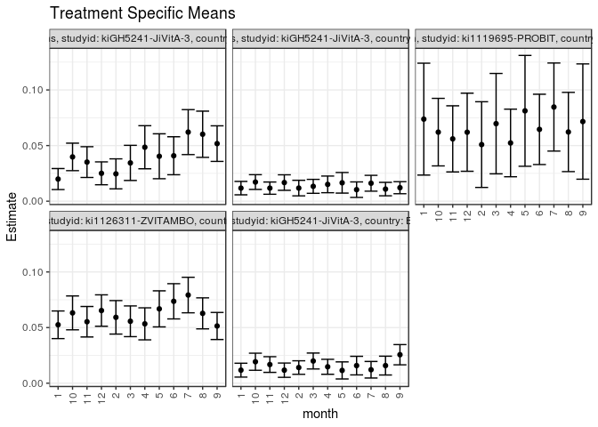

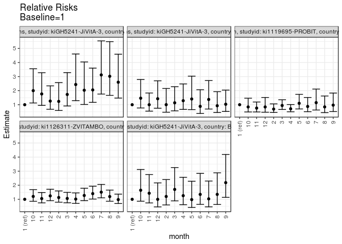

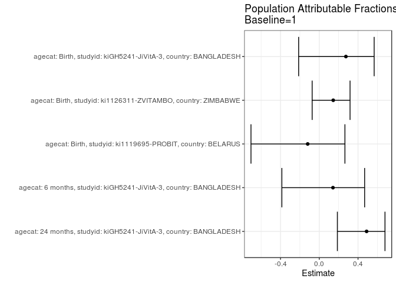

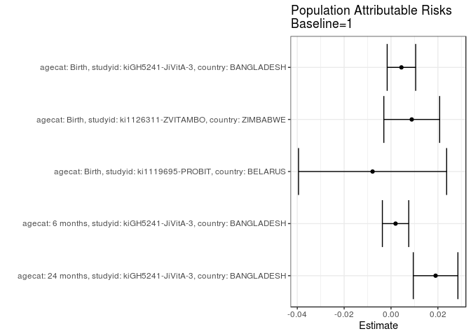

## Results Table

### Parameter: TSM

| agecat | studyid | country | intervention_level | baseline_level | estimate | ci_lower | ci_upper |
| --- | --- | --- | --- | --- | --- | --- | --- |
| Birth | ki1119695-PROBIT | BELARUS | 1 | NA | 0.0737705 | 0.0234941 | 0.1240469 |
| Birth | ki1119695-PROBIT | BELARUS | 2 | NA | 0.0508906 | 0.0123799 | 0.0894013 |
| Birth | ki1119695-PROBIT | BELARUS | 3 | NA | 0.0697190 | 0.0246172 | 0.1148209 |
| Birth | ki1119695-PROBIT | BELARUS | 4 | NA | 0.0523560 | 0.0219843 | 0.0827277 |
| Birth | ki1119695-PROBIT | BELARUS | 5 | NA | 0.0812236 | 0.0314005 | 0.1310468 |
| Birth | ki1119695-PROBIT | BELARUS | 6 | NA | 0.0645482 | 0.0329448 | 0.0961515 |
| Birth | ki1119695-PROBIT | BELARUS | 7 | NA | 0.0846395 | 0.0450669 | 0.1242121 |
| Birth | ki1119695-PROBIT | BELARUS | 8 | NA | 0.0622155 | 0.0266118 | 0.0978192 |
| Birth | ki1119695-PROBIT | BELARUS | 9 | NA | 0.0715918 | 0.0197862 | 0.1233974 |
| Birth | ki1119695-PROBIT | BELARUS | 10 | NA | 0.0620828 | 0.0317130 | 0.0924525 |
| Birth | ki1119695-PROBIT | BELARUS | 11 | NA | 0.0560345 | 0.0263187 | 0.0857503 |
| Birth | ki1119695-PROBIT | BELARUS | 12 | NA | 0.0620053 | 0.0268989 | 0.0971117 |
| Birth | ki1126311-ZVITAMBO | ZIMBABWE | 1 | NA | 0.0525040 | 0.0400792 | 0.0649288 |
| Birth | ki1126311-ZVITAMBO | ZIMBABWE | 2 | NA | 0.0591966 | 0.0441577 | 0.0742356 |
| Birth | ki1126311-ZVITAMBO | ZIMBABWE | 3 | NA | 0.0556604 | 0.0418581 | 0.0694626 |
| Birth | ki1126311-ZVITAMBO | ZIMBABWE | 4 | NA | 0.0533618 | 0.0389704 | 0.0677532 |
| Birth | ki1126311-ZVITAMBO | ZIMBABWE | 5 | NA | 0.0668127 | 0.0506154 | 0.0830100 |
| Birth | ki1126311-ZVITAMBO | ZIMBABWE | 6 | NA | 0.0736138 | 0.0577876 | 0.0894399 |
| Birth | ki1126311-ZVITAMBO | ZIMBABWE | 7 | NA | 0.0792350 | 0.0632579 | 0.0952120 |
| Birth | ki1126311-ZVITAMBO | ZIMBABWE | 8 | NA | 0.0627687 | 0.0488285 | 0.0767089 |
| Birth | ki1126311-ZVITAMBO | ZIMBABWE | 9 | NA | 0.0514241 | 0.0392479 | 0.0636002 |
| Birth | ki1126311-ZVITAMBO | ZIMBABWE | 10 | NA | 0.0632008 | 0.0479738 | 0.0784278 |
| Birth | ki1126311-ZVITAMBO | ZIMBABWE | 11 | NA | 0.0552434 | 0.0415416 | 0.0689453 |
| Birth | ki1126311-ZVITAMBO | ZIMBABWE | 12 | NA | 0.0653096 | 0.0512060 | 0.0794132 |
| Birth | kiGH5241-JiVitA-3 | BANGLADESH | 1 | NA | 0.0117241 | 0.0054908 | 0.0179574 |
| Birth | kiGH5241-JiVitA-3 | BANGLADESH | 2 | NA | 0.0140735 | 0.0079946 | 0.0201523 |
| Birth | kiGH5241-JiVitA-3 | BANGLADESH | 3 | NA | 0.0199485 | 0.0127994 | 0.0270976 |
| Birth | kiGH5241-JiVitA-3 | BANGLADESH | 4 | NA | 0.0147569 | 0.0080266 | 0.0214873 |
| Birth | kiGH5241-JiVitA-3 | BANGLADESH | 5 | NA | 0.0114796 | 0.0038025 | 0.0191567 |
| Birth | kiGH5241-JiVitA-3 | BANGLADESH | 6 | NA | 0.0158151 | 0.0074545 | 0.0241756 |
| Birth | kiGH5241-JiVitA-3 | BANGLADESH | 7 | NA | 0.0121012 | 0.0046610 | 0.0195414 |
| Birth | kiGH5241-JiVitA-3 | BANGLADESH | 8 | NA | 0.0158333 | 0.0073862 | 0.0242805 |
| Birth | kiGH5241-JiVitA-3 | BANGLADESH | 9 | NA | 0.0256074 | 0.0165305 | 0.0346842 |
| Birth | kiGH5241-JiVitA-3 | BANGLADESH | 10 | NA | 0.0192887 | 0.0116156 | 0.0269619 |
| Birth | kiGH5241-JiVitA-3 | BANGLADESH | 11 | NA | 0.0167765 | 0.0097178 | 0.0238353 |
| Birth | kiGH5241-JiVitA-3 | BANGLADESH | 12 | NA | 0.0117096 | 0.0052904 | 0.0181288 |
| 6 months | kiGH5241-JiVitA-3 | BANGLADESH | 1 | NA | 0.0117647 | 0.0057455 | 0.0177839 |
| 6 months | kiGH5241-JiVitA-3 | BANGLADESH | 2 | NA | 0.0118044 | 0.0048058 | 0.0188030 |
| 6 months | kiGH5241-JiVitA-3 | BANGLADESH | 3 | NA | 0.0133709 | 0.0071023 | 0.0196395 |
| 6 months | kiGH5241-JiVitA-3 | BANGLADESH | 4 | NA | 0.0151261 | 0.0076523 | 0.0225998 |
| 6 months | kiGH5241-JiVitA-3 | BANGLADESH | 5 | NA | 0.0165505 | 0.0072959 | 0.0258051 |
| 6 months | kiGH5241-JiVitA-3 | BANGLADESH | 6 | NA | 0.0103806 | 0.0034223 | 0.0173389 |
| 6 months | kiGH5241-JiVitA-3 | BANGLADESH | 7 | NA | 0.0161551 | 0.0090400 | 0.0232702 |
| 6 months | kiGH5241-JiVitA-3 | BANGLADESH | 8 | NA | 0.0109066 | 0.0048820 | 0.0169312 |
| 6 months | kiGH5241-JiVitA-3 | BANGLADESH | 9 | NA | 0.0121561 | 0.0067483 | 0.0175639 |
| 6 months | kiGH5241-JiVitA-3 | BANGLADESH | 10 | NA | 0.0172209 | 0.0105905 | 0.0238513 |
| 6 months | kiGH5241-JiVitA-3 | BANGLADESH | 11 | NA | 0.0117578 | 0.0062622 | 0.0172533 |
| 6 months | kiGH5241-JiVitA-3 | BANGLADESH | 12 | NA | 0.0167665 | 0.0098008 | 0.0237321 |
| 24 months | kiGH5241-JiVitA-3 | BANGLADESH | 1 | NA | 0.0199147 | 0.0104697 | 0.0293596 |
| 24 months | kiGH5241-JiVitA-3 | BANGLADESH | 2 | NA | 0.0245902 | 0.0110910 | 0.0380894 |
| 24 months | kiGH5241-JiVitA-3 | BANGLADESH | 3 | NA | 0.0344353 | 0.0186490 | 0.0502215 |
| 24 months | kiGH5241-JiVitA-3 | BANGLADESH | 4 | NA | 0.0485075 | 0.0291374 | 0.0678775 |
| 24 months | kiGH5241-JiVitA-3 | BANGLADESH | 5 | NA | 0.0404040 | 0.0202058 | 0.0606023 |
| 24 months | kiGH5241-JiVitA-3 | BANGLADESH | 6 | NA | 0.0408526 | 0.0237708 | 0.0579343 |
| 24 months | kiGH5241-JiVitA-3 | BANGLADESH | 7 | NA | 0.0621118 | 0.0419247 | 0.0822989 |
| 24 months | kiGH5241-JiVitA-3 | BANGLADESH | 8 | NA | 0.0601852 | 0.0394079 | 0.0809624 |
| 24 months | kiGH5241-JiVitA-3 | BANGLADESH | 9 | NA | 0.0517711 | 0.0357756 | 0.0677667 |
| 24 months | kiGH5241-JiVitA-3 | BANGLADESH | 10 | NA | 0.0398180 | 0.0274712 | 0.0521647 |
| 24 months | kiGH5241-JiVitA-3 | BANGLADESH | 11 | NA | 0.0351603 | 0.0213196 | 0.0490010 |
| 24 months | kiGH5241-JiVitA-3 | BANGLADESH | 12 | NA | 0.0250627 | 0.0147819 | 0.0353434 |

### Parameter: E(Y)

| agecat | studyid | country | intervention_level | baseline_level | estimate | ci_lower | ci_upper |
| --- | --- | --- | --- | --- | --- | --- | --- |
| Birth | ki1119695-PROBIT | BELARUS | NA | NA | 0.0658999 | 0.0328405 | 0.0989593 |
| Birth | ki1126311-ZVITAMBO | ZIMBABWE | NA | NA | 0.0613511 | 0.0572087 | 0.0654935 |
| Birth | kiGH5241-JiVitA-3 | BANGLADESH | NA | NA | 0.0161691 | 0.0138058 | 0.0185324 |
| 6 months | kiGH5241-JiVitA-3 | BANGLADESH | NA | NA | 0.0137035 | 0.0116269 | 0.0157801 |
| 24 months | kiGH5241-JiVitA-3 | BANGLADESH | NA | NA | 0.0389399 | 0.0346167 | 0.0432631 |

### Parameter: RR

| agecat | studyid | country | intervention_level | baseline_level | estimate | ci_lower | ci_upper |
| --- | --- | --- | --- | --- | --- | --- | --- |
| Birth | ki1119695-PROBIT | BELARUS | 1 | 1 | 1.0000000 | 1.0000000 | 1.000000 |
| Birth | ki1119695-PROBIT | BELARUS | 2 | 1 | 0.6898502 | 0.4492995 | 1.059190 |
| Birth | ki1119695-PROBIT | BELARUS | 3 | 1 | 0.9450804 | 0.6617226 | 1.349775 |
| Birth | ki1119695-PROBIT | BELARUS | 4 | 1 | 0.7097150 | 0.4971546 | 1.013156 |
| Birth | ki1119695-PROBIT | BELARUS | 5 | 1 | 1.1010314 | 0.6971109 | 1.738992 |
| Birth | ki1119695-PROBIT | BELARUS | 6 | 1 | 0.8749862 | 0.5056793 | 1.514005 |
| Birth | ki1119695-PROBIT | BELARUS | 7 | 1 | 1.1473354 | 0.6235454 | 2.111119 |
| Birth | ki1119695-PROBIT | BELARUS | 8 | 1 | 0.8433654 | 0.4391192 | 1.619754 |
| Birth | ki1119695-PROBIT | BELARUS | 9 | 1 | 0.9704663 | 0.5149391 | 1.828963 |
| Birth | ki1119695-PROBIT | BELARUS | 10 | 1 | 0.8415665 | 0.4839723 | 1.463378 |
| Birth | ki1119695-PROBIT | BELARUS | 11 | 1 | 0.7595785 | 0.4829786 | 1.194586 |
| Birth | ki1119695-PROBIT | BELARUS | 12 | 1 | 0.8405160 | 0.4665145 | 1.514352 |
| Birth | ki1126311-ZVITAMBO | ZIMBABWE | 1 | 1 | 1.0000000 | 1.0000000 | 1.000000 |
| Birth | ki1126311-ZVITAMBO | ZIMBABWE | 2 | 1 | 1.1274679 | 0.7967471 | 1.595467 |
| Birth | ki1126311-ZVITAMBO | ZIMBABWE | 3 | 1 | 1.0601161 | 0.7524723 | 1.493538 |
| Birth | ki1126311-ZVITAMBO | ZIMBABWE | 4 | 1 | 1.0163369 | 0.7099272 | 1.454995 |
| Birth | ki1126311-ZVITAMBO | ZIMBABWE | 5 | 1 | 1.2725251 | 0.9068504 | 1.785653 |
| Birth | ki1126311-ZVITAMBO | ZIMBABWE | 6 | 1 | 1.4020591 | 1.0183890 | 1.930274 |
| Birth | ki1126311-ZVITAMBO | ZIMBABWE | 7 | 1 | 1.5091215 | 1.1058627 | 2.059431 |
| Birth | ki1126311-ZVITAMBO | ZIMBABWE | 8 | 1 | 1.1955023 | 0.8641832 | 1.653846 |
| Birth | ki1126311-ZVITAMBO | ZIMBABWE | 9 | 1 | 0.9794304 | 0.7007909 | 1.368859 |
| Birth | ki1126311-ZVITAMBO | ZIMBABWE | 10 | 1 | 1.2037325 | 0.8587448 | 1.687313 |
| Birth | ki1126311-ZVITAMBO | ZIMBABWE | 11 | 1 | 1.0521752 | 0.7468062 | 1.482409 |
| Birth | ki1126311-ZVITAMBO | ZIMBABWE | 12 | 1 | 1.2438964 | 0.9029225 | 1.713634 |
| Birth | kiGH5241-JiVitA-3 | BANGLADESH | 1 | 1 | 1.0000000 | 1.0000000 | 1.000000 |
| Birth | kiGH5241-JiVitA-3 | BANGLADESH | 2 | 1 | 1.2003863 | 0.5993170 | 2.404282 |
| Birth | kiGH5241-JiVitA-3 | BANGLADESH | 3 | 1 | 1.7014914 | 0.8889762 | 3.256637 |
| Birth | kiGH5241-JiVitA-3 | BANGLADESH | 4 | 1 | 1.2586806 | 0.6177433 | 2.564620 |
| Birth | kiGH5241-JiVitA-3 | BANGLADESH | 5 | 1 | 0.9791417 | 0.4196428 | 2.284606 |
| Birth | kiGH5241-JiVitA-3 | BANGLADESH | 6 | 1 | 1.3489337 | 0.6400836 | 2.842789 |
| Birth | kiGH5241-JiVitA-3 | BANGLADESH | 7 | 1 | 1.0321620 | 0.4637005 | 2.297514 |
| Birth | kiGH5241-JiVitA-3 | BANGLADESH | 8 | 1 | 1.3504902 | 0.6327158 | 2.882532 |
| Birth | kiGH5241-JiVitA-3 | BANGLADESH | 9 | 1 | 2.1841567 | 1.1391968 | 4.187635 |
| Birth | kiGH5241-JiVitA-3 | BANGLADESH | 10 | 1 | 1.6452150 | 0.8682688 | 3.117390 |
| Birth | kiGH5241-JiVitA-3 | BANGLADESH | 11 | 1 | 1.4309379 | 0.7423498 | 2.758246 |
| Birth | kiGH5241-JiVitA-3 | BANGLADESH | 12 | 1 | 0.9987602 | 0.4600776 | 2.168160 |
| 6 months | kiGH5241-JiVitA-3 | BANGLADESH | 1 | 1 | 1.0000000 | 1.0000000 | 1.000000 |
| 6 months | kiGH5241-JiVitA-3 | BANGLADESH | 2 | 1 | 1.0033727 | 0.4670055 | 2.155770 |
| 6 months | kiGH5241-JiVitA-3 | BANGLADESH | 3 | 1 | 1.1365236 | 0.5660701 | 2.281848 |
| 6 months | kiGH5241-JiVitA-3 | BANGLADESH | 4 | 1 | 1.2857143 | 0.6678731 | 2.475113 |
| 6 months | kiGH5241-JiVitA-3 | BANGLADESH | 5 | 1 | 1.4067944 | 0.6527698 | 3.031804 |
| 6 months | kiGH5241-JiVitA-3 | BANGLADESH | 6 | 1 | 0.8823529 | 0.3769364 | 2.065459 |
| 6 months | kiGH5241-JiVitA-3 | BANGLADESH | 7 | 1 | 1.3731826 | 0.6937160 | 2.718159 |
| 6 months | kiGH5241-JiVitA-3 | BANGLADESH | 8 | 1 | 0.9270620 | 0.4462706 | 1.925836 |
| 6 months | kiGH5241-JiVitA-3 | BANGLADESH | 9 | 1 | 1.0332694 | 0.5233273 | 2.040111 |
| 6 months | kiGH5241-JiVitA-3 | BANGLADESH | 10 | 1 | 1.4637767 | 0.7673756 | 2.792169 |
| 6 months | kiGH5241-JiVitA-3 | BANGLADESH | 11 | 1 | 0.9994121 | 0.5452462 | 1.831878 |
| 6 months | kiGH5241-JiVitA-3 | BANGLADESH | 12 | 1 | 1.4251497 | 0.7522641 | 2.699918 |
| 24 months | kiGH5241-JiVitA-3 | BANGLADESH | 1 | 1 | 1.0000000 | 1.0000000 | 1.000000 |
| 24 months | kiGH5241-JiVitA-3 | BANGLADESH | 2 | 1 | 1.2347775 | 0.5925301 | 2.573161 |
| 24 months | kiGH5241-JiVitA-3 | BANGLADESH | 3 | 1 | 1.7291421 | 0.9112173 | 3.281250 |
| 24 months | kiGH5241-JiVitA-3 | BANGLADESH | 4 | 1 | 2.4357676 | 1.2889145 | 4.603070 |
| 24 months | kiGH5241-JiVitA-3 | BANGLADESH | 5 | 1 | 2.0288600 | 1.0186858 | 4.040768 |
| 24 months | kiGH5241-JiVitA-3 | BANGLADESH | 6 | 1 | 2.0513829 | 1.1684623 | 3.601461 |
| 24 months | kiGH5241-JiVitA-3 | BANGLADESH | 7 | 1 | 3.1188997 | 1.7571411 | 5.536001 |
| 24 months | kiGH5241-JiVitA-3 | BANGLADESH | 8 | 1 | 3.0221561 | 1.6654022 | 5.484217 |
| 24 months | kiGH5241-JiVitA-3 | BANGLADESH | 9 | 1 | 2.5996496 | 1.4718921 | 4.591490 |
| 24 months | kiGH5241-JiVitA-3 | BANGLADESH | 10 | 1 | 1.9994312 | 1.1247045 | 3.554467 |
| 24 months | kiGH5241-JiVitA-3 | BANGLADESH | 11 | 1 | 1.7655488 | 0.9520498 | 3.274159 |
| 24 months | kiGH5241-JiVitA-3 | BANGLADESH | 12 | 1 | 1.2585034 | 0.6766223 | 2.340790 |

### Parameter: PAR

| agecat | studyid | country | intervention_level | baseline_level | estimate | ci_lower | ci_upper |
| --- | --- | --- | --- | --- | --- | --- | --- |
| Birth | ki1119695-PROBIT | BELARUS | 1 | NA | -0.0078706 | -0.0394790 | 0.0237378 |
| Birth | ki1126311-ZVITAMBO | ZIMBABWE | 1 | NA | 0.0088471 | -0.0030646 | 0.0207588 |
| Birth | kiGH5241-JiVitA-3 | BANGLADESH | 1 | NA | 0.0044449 | -0.0016367 | 0.0105266 |
| 6 months | kiGH5241-JiVitA-3 | BANGLADESH | 1 | NA | 0.0019388 | -0.0036848 | 0.0075625 |
| 24 months | kiGH5241-JiVitA-3 | BANGLADESH | 1 | NA | 0.0190253 | 0.0095017 | 0.0285488 |

### Parameter: PAF

| agecat | studyid | country | intervention_level | baseline_level | estimate | ci_lower | ci_upper |
| --- | --- | --- | --- | --- | --- | --- | --- |
| Birth | ki1119695-PROBIT | BELARUS | 1 | NA | -0.1194328 | -0.7047252 | 0.2649081 |
| Birth | ki1126311-ZVITAMBO | ZIMBABWE | 1 | NA | 0.1442041 | -0.0734687 | 0.3177382 |
| Birth | kiGH5241-JiVitA-3 | BANGLADESH | 1 | NA | 0.2749036 | -0.2129487 | 0.5665400 |
| 6 months | kiGH5241-JiVitA-3 | BANGLADESH | 1 | NA | 0.1414834 | -0.3860040 | 0.4682189 |
| 24 months | kiGH5241-JiVitA-3 | BANGLADESH | 1 | NA | 0.4885799 | 0.1868143 | 0.6783631 |